# Portfolio 7

Rachel Wood

2023-04-20

# Task 1

1. A function $k$ is a kernel if it is semi-definite (by Mercer’s Theorem), i.e.
   $$\sum_{i = 1}^n \sum_{j=1}^n c_i c_j k(x_i, x_j)$$
   for all points $x_1, \ldots, x_n \in \mathcal{X}$ and $c_1, \ldots, c_n \in \mathbb{R}$ For $k(x, x') = g(x) g(x')$ for $g : \mathcal{X} \to \mathbb{R}$ we can see:
   $$\sum_{i = 1}^n \sum_{j=1}^n c_i c_j g(x_i)
   g(x_j) = \left(\sum_{i = 1}^n c_i g(x_i) \right)\left( \sum_{j = 1}^n
   c_j g(x_j) \right) = \left(\sum_{i = 1}^n c_i g(x_i) \right)^2 \geq
   0$$
   so $k$ is a kernel.
2. If we set $g(x) = \sqrt{a}$ for all $x \in \mathcal{X}$ in the above example, then $k(x, x') = g(x) g(x') = a$ is a kernel.
3. For kernels $\{k_l \}_{l=1}^m$ and constants $\{b_l \}_{l=1}^m$, $k = \sum_{l=1}^m b_l k_l$ satisfies:
   $$\sum_{i = 1}^n \sum_{j=1}^n c_i c_j k(x_i,
   x_j) = \sum_{i = 1}^n \sum_{j=1}^n c_i c_j \sum_{l=1}^m b_l k_l(x_i,
   x_j) = \sum_{l =1}^m b_l \sum_{i = 1}^n \sum_{j=1}^n c_i c_j k_l(x_i,
   x_j) \geq 0$$
   as $\sum_{j=1}^n c_i c_j k_l(x_i, x_j) \geq 0$ due to $k_l$ being a kernel and all $b_l$ are non-negative.

# Task 2

For this task we use the bone mineral density dataset obtained from the Elements of Statistical learning

```r
data <- read.csv("spnbmd.csv", sep = "\t")
head(data)
```

```
##   idnum   age gender      spnbmd
## 1     1 11.70   male 0.018080670
## 2     1 12.70   male 0.060109290
## 3     1 13.75   male 0.005857545
## 4     2 13.25   male 0.010263930
## 5     2 14.30   male 0.210526300
## 6     2 15.30   male 0.040843210
```

We compute the posterior using an empirical Bayes approach, where we choose $(\lambda, \psi) = (\lambda_n, \psi_n)$ given by maximisers of the marginal likelihood:
$$(\lambda_n, \psi_n) \in \mathop{\mathrm{arg\,max}}_{\lambda, \psi}
\left( -\frac{1}{2} \log|\mathbf{K}_n +\lambda \mathbf{I}_n| -
\frac{1}{2} y_{1:n}^0 (\mathbf{K}_n + \lambda \mathbf{I}_n)^{-1}
y_{1:n}^0 \right)$$
We first create a function to compute the value of the objective function:

```r
marginal_likelihood <- function(par, x, y){
  n <- length(x)
  lambda <- par[1]
  psi <- par[2]

  K <- kernelMatrix(rbfdot(psi), x)
  Klam <- K + lambda * diag(n)
  alpha <- solve(Klam) %*% y
  out <- -0.5*(log( det(Klam) ) + t(y) %*% alpha)
  if(is.finite(out)){
    return(out)
  } else {
    return(-100000 + sum(log(par)))
  }
}
```

```r
library(Matrix)
library(kernlab)
#data <- data[(data$gender == "female"),]

y <- as.vector(data$spnbmd)
x <- as.vector(data$age)

marginal_likelihood(c(1, 4), x, y)
```

```
##           [,1]
## [1,] -44.43485
```

```r
negml <- function(par, x, y)-marginal_likelihood(par, x, y)
```

We now use the `optim` function to find the empirical bayes estimator of $(\lambda, \psi)$

```r
guess <- c(0.01, 0.5)
opt <- optim(guess, negml, x = x, y = y)
lambda <- opt$par[1]
psi <- opt$par[2]
```

## Computing Posterior and Credible Interval

The posterior $f|y_{1:n} \sim GP(f_n, k_n)$ where

$$f_n(x) = k_n(x)^T \left(\mathbf{K}_n + \lambda \mathbf{I}_n \right)^{-1}
y_{1:n} \\
k_n(x,x') = k(x, x') - k(x)^T \left(\mathbf{K}_n + \lambda
\mathbf{I}_n \right)^{-1} k(x')$$
We code these functions below:

```r
f_n <- function(x_new, x, y, lambda, psi){
  n <- length(x)

  K <- kernelMatrix(rbfdot(psi), x)

  kn <- kernelMatrix(rbfdot(psi), x, x_new)
  f <- t(kn) %*% solve(K + lambda* diag(n)) %*% y
  return(f)
}

k_n <- function(x0, x1, x, y,lambda,psi){
  n <- length(x)
  K <- kernelMatrix(rbfdot(psi), x)
  k <- kernelMatrix(rbfdot(psi), x0,x1)

  k_x0 <- kernelMatrix(rbfdot(psi), x ,x0)
  k_x1 <- kernelMatrix(rbfdot(psi), x ,x1)

  out <- k - t(k_x0) %*% solve(K + lambda * diag(n)) %*% k_x1
  return(out)
}
```

Further the credible interval for the posterior is given by:
$$C_{\alpha}(x) = \left[ f_n(x) - z_{1 - \alpha/2} \sqrt{k_n(x,x)} , \
f_n(x) + z_{1 - \alpha/2} \sqrt{k_n(x,x)} \ \right]$$
and so we can now plot the mean function and the credible interval for the GP fitted to our data with the empirical bayes $(\lambda, \psi)$:

```r
credible_int <- function(x_new, x, y, lambda, psi, alpha = 0.05){
  mean <- f_n(x_new,x, y, lambda, psi)

  k_n_xx <- diag(k_n(x_new, x_new, x, y, lambda, psi))

  ci_lower <- mean - qnorm(alpha/2,lower.tail = FALSE) * sqrt(k_n_xx)
  ci_upper <- mean + qnorm(alpha/2,lower.tail = FALSE) * sqrt(k_n_xx)

  return(cbind(ci_lower, ci_upper))
}
```

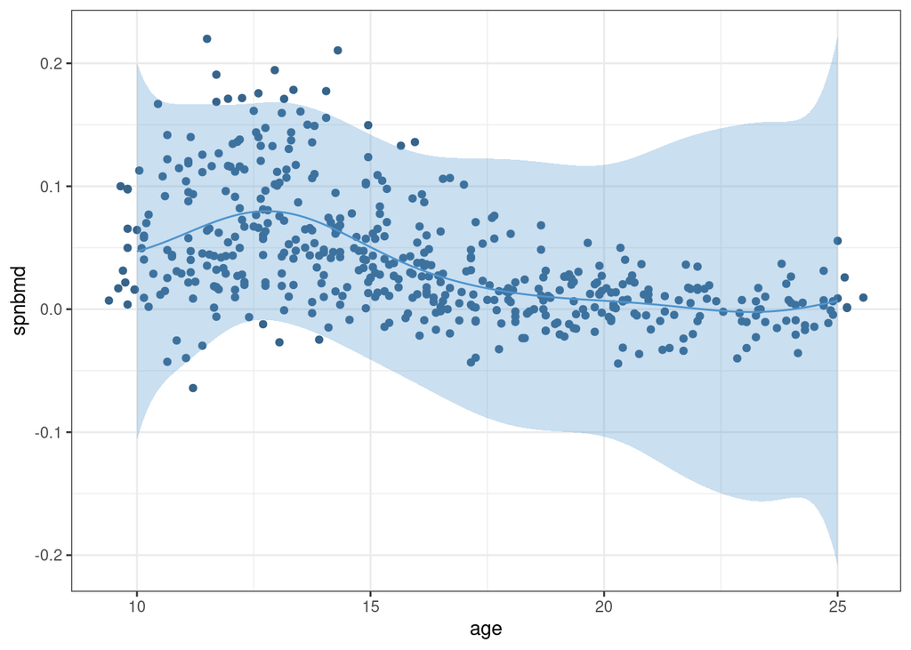

```r
library(dplyr)
library(ggplot2)

x_seq <- seq(10, 25, 0.1)

mean_f <- as.vector(f_n(x_seq,x, y, lambda, psi ))

ci <- credible_int(x_seq, x, y, lambda, psi)

plot_dat <- tibble(x = x_seq, mean = mean_f, lower = ci[,1], upper = ci[,2])

data <- as_tibble(data)

ggplot(data = data, aes(x = age, y = spnbmd)) +
  geom_point(colour = "steelblue4") +
  geom_line(data = plot_dat, mapping = aes(x = x, y = mean), colour = "steelblue3") +
  geom_ribbon(data = plot_dat, inherit.aes = FALSE, mapping =  aes(x = x, ymin = lower, ymax = upper), alpha = 0.3, fill = "steelblue3")
```